# Brexit

Noah

2025-03-25

In September 2019, YouGov survey asked 1,639 GB adults the following question:

> In hindsight, do you think Britain was right/wrong to vote to leave EU?
> - Right to leave
> - Wrong to leave
> - Don’t know

The data from the survey is in `data/brexit.csv`.

```r
brexit <- read_csv("data/brexit.csv")
```

In the course video, we made the following vizualisation.

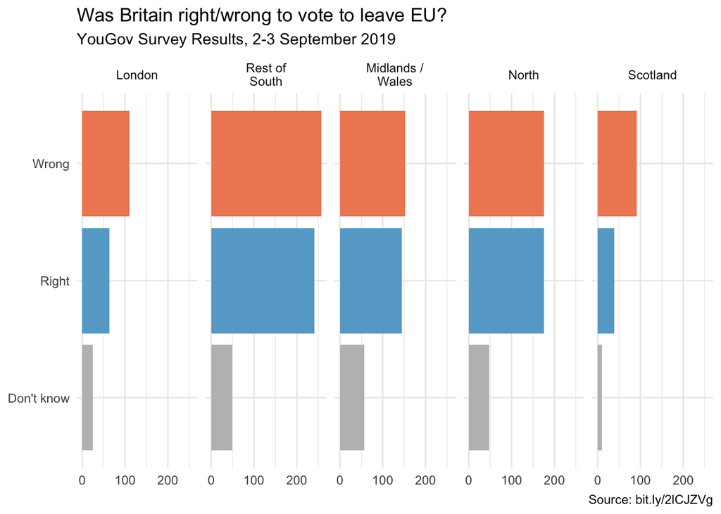

```r
brexit <- brexit %>%
  mutate(
    region = fct_relevel(region, "london", "rest_of_south", "midlands_wales", "north", "scot"),
    region = fct_recode(region, London = "london", `Rest of South` = "rest_of_south", `Midlands / Wales` = "midlands_wales", North = "north", Scotland = "scot")
  )

ggplot(brexit, aes(y = opinion, fill = opinion)) +
  geom_bar() +
  facet_wrap(~region, nrow = 1, labeller = label_wrap_gen(width = 12)) +
  guides(fill = FALSE) +
  labs(
    title = "Was Britain right/wrong to vote to leave EU?",
    subtitle = "YouGov Survey Results, 2-3 September 2019",
    caption = "Source: bit.ly/2lCJZVg",
    x = NULL, y = NULL
  ) +
  scale_fill_manual(values = c(
    "Wrong" = "#ef8a62",
    "Right" = "#67a9cf",
    "Don't know" = "gray"
  )) +
  theme_minimal()
```

In this application exercise, let’s tell a different story with the same data.

### Exercise 1 - Free scales

Add `scales = "free_x"` as an argument to the `facet_wrap()` function.

How does the visualisation change?

How is the story this visualisation telling different than the story the original plot tells?

It changes the scales of the x axes for each plot, making the largest bar (wrong) appear to be the same size in each plot. Unless you refer to the scales of the x-axes, you would not as easily see the different sample sizes from each region. But you can perhaps more easily compare the differences in proportion of opinions (e.g., how close to 50/50 were right vs wrong opinions) across the regions.

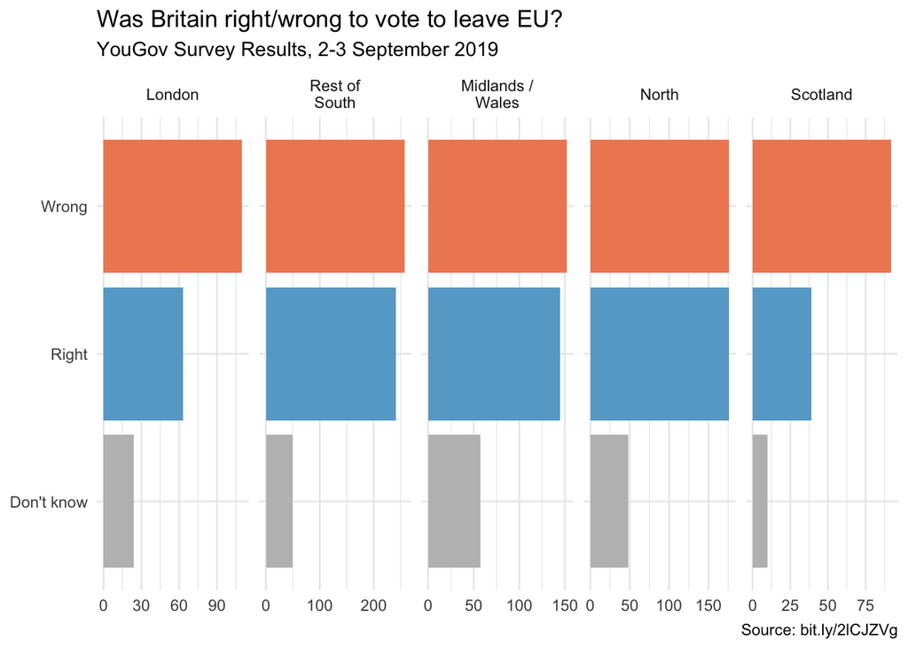

```r
ggplot(brexit, aes(y = opinion, fill = opinion)) +
  geom_bar() +
  facet_wrap(~region,
    nrow = 1, labeller = label_wrap_gen(width = 12),
    scales = "free_x"
  ) +
  guides(fill = FALSE) +
  labs(
    title = "Was Britain right/wrong to vote to leave EU?",
    subtitle = "YouGov Survey Results, 2-3 September 2019",
    caption = "Source: bit.ly/2lCJZVg",
    x = NULL, y = NULL
  ) +
  scale_fill_manual(values = c(
    "Wrong" = "#ef8a62",
    "Right" = "#67a9cf",
    "Don't know" = "gray"
  )) +
  theme_minimal()
```

### Exercise 2 - Comparing proportions across facets

First, calculate the proportion of wrong, right, and don’t know answers in each category and then plot these proportions (rather than the counts) and then improve axis labeling. How is the story this visualisation telling different than the story the original plot tells? **Hint:** You’ll need the **scales** package to improve axis labeling, which means you’ll need to load it on top of the document as well.

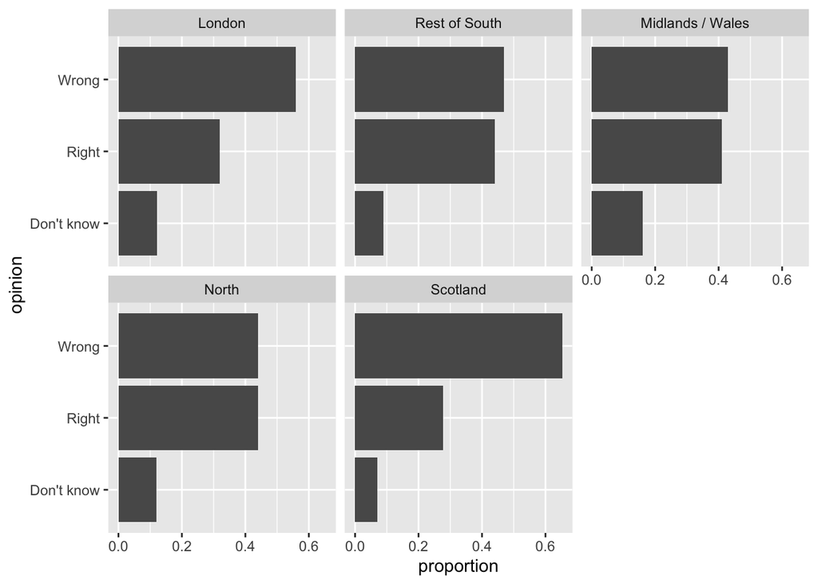

```r
#creating a dataframe which shows the counts of unique combinations of region and opinion
opinions_by_region <- brexit %>%
  count(region, opinion)
#creating a dataframe which shows the total observations per region
regions_total <- brexit %>%
  count(region) %>%
  rename(total = n)
#creating a dataframe which shows the proportion of each opinion per region
brexit_proportions <- opinions_by_region %>%
  left_join(regions_total, by = "region") %>%
  mutate(proportion = n/total)
#plotting proportions
#must use geom_col( ) instead of geom_bar( ) so we can plot proportions instead of counts.
ggplot(brexit_proportions, aes(x = proportion, y = opinion)) +
  geom_col() +
  facet_wrap(~region)
```

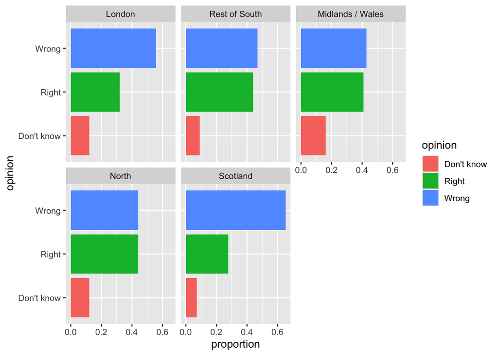

```r
#applying a fill to the bars based on value of opinion.
ggplot(brexit_proportions, aes(x = proportion, y = opinion, fill = opinion)) +
  geom_col() +
  facet_wrap(~region)
```

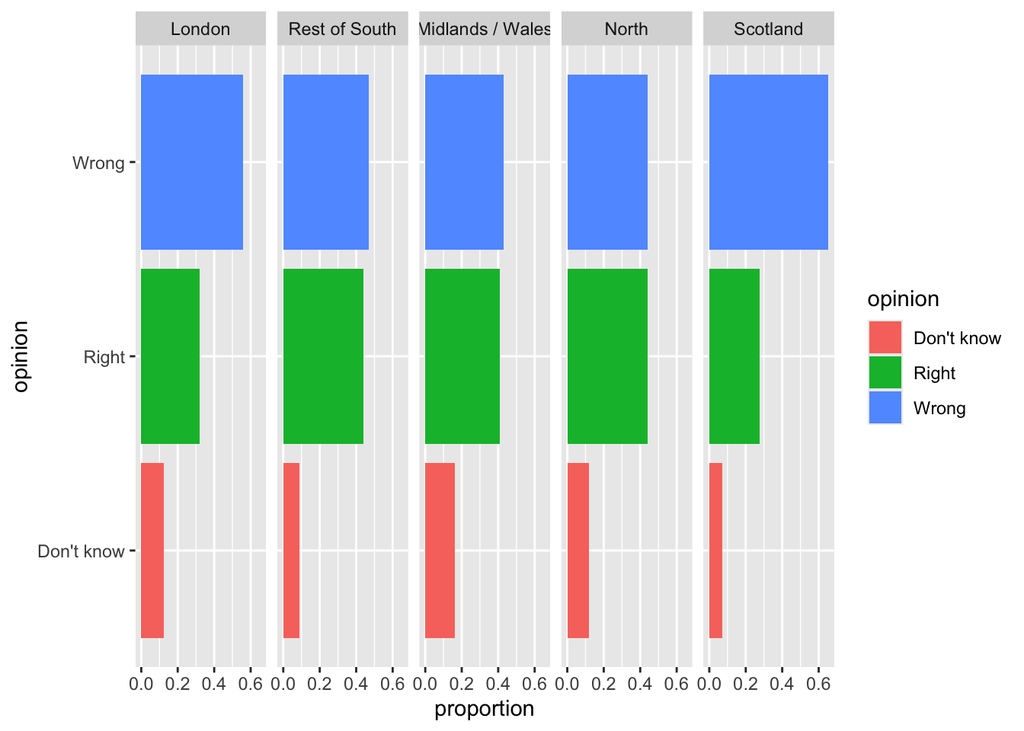

```r
#making the faceted plot have only 1 row.
ggplot(brexit_proportions, aes(x = proportion, y = opinion, fill = opinion)) +
  geom_col() +
  facet_wrap(~region, nrow = 1)
```

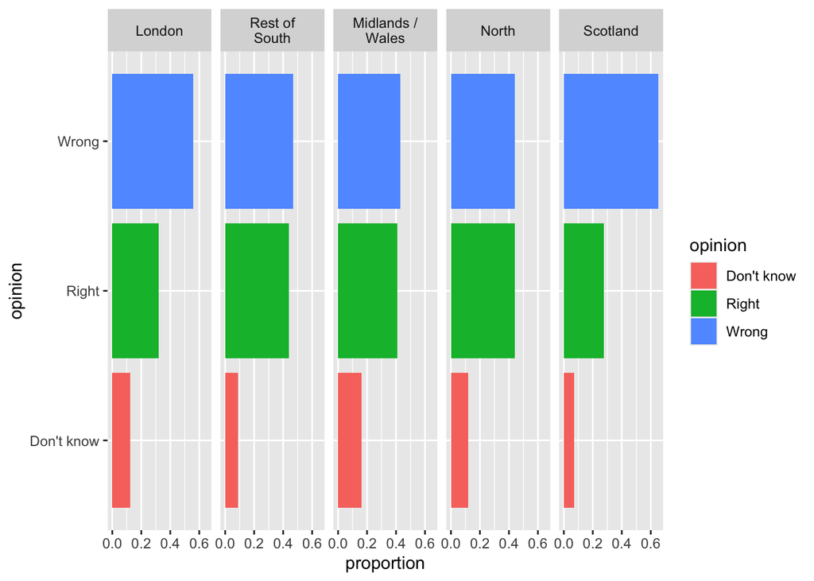

```r
#making the text of the facet labels (region names) wrap (go to a new line) after 12 characters.
ggplot(brexit_proportions, aes(x = proportion, y = opinion, fill = opinion)) +
  geom_col() +
  facet_wrap(~region, nrow = 1, labeller = label_wrap_gen(width = 12))
```

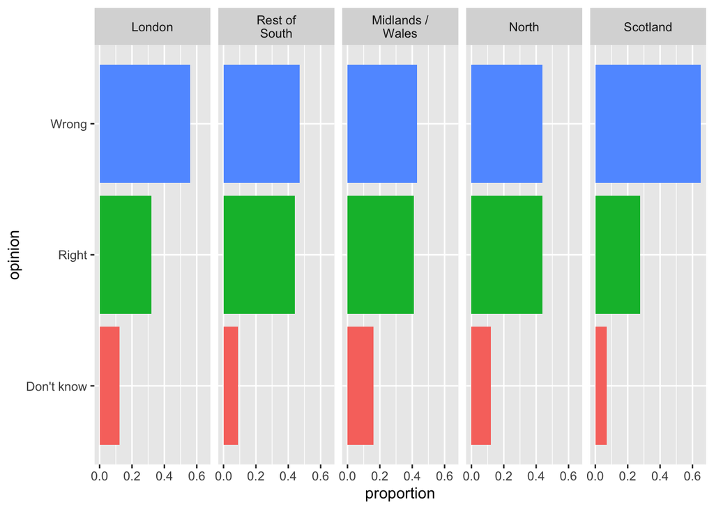

```r
#removing the fill legend for opinion (not needed since the y axis is labeled) to give more room.
ggplot(brexit_proportions, aes(x = proportion, y = opinion, fill = opinion)) +
  geom_col() +
  facet_wrap(~region, nrow = 1, labeller = label_wrap_gen(width = 12)) +
  guides(fill = FALSE)
```

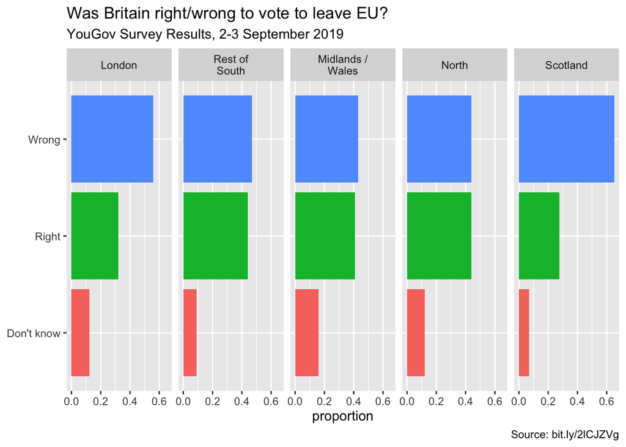

```r
#Adding title, subtitle, and caption, and removing y axis label.
ggplot(brexit_proportions, aes(x = proportion, y = opinion, fill = opinion)) +
  geom_col() +
  facet_wrap(~region, nrow = 1, labeller = label_wrap_gen(width = 12)) +
  guides(fill = FALSE)+
  labs(
    title = "Was Britain right/wrong to vote to leave EU?",
    subtitle = "YouGov Survey Results, 2-3 September 2019",
    caption = "Source: bit.ly/2lCJZVg",
    y = NULL
  )
```

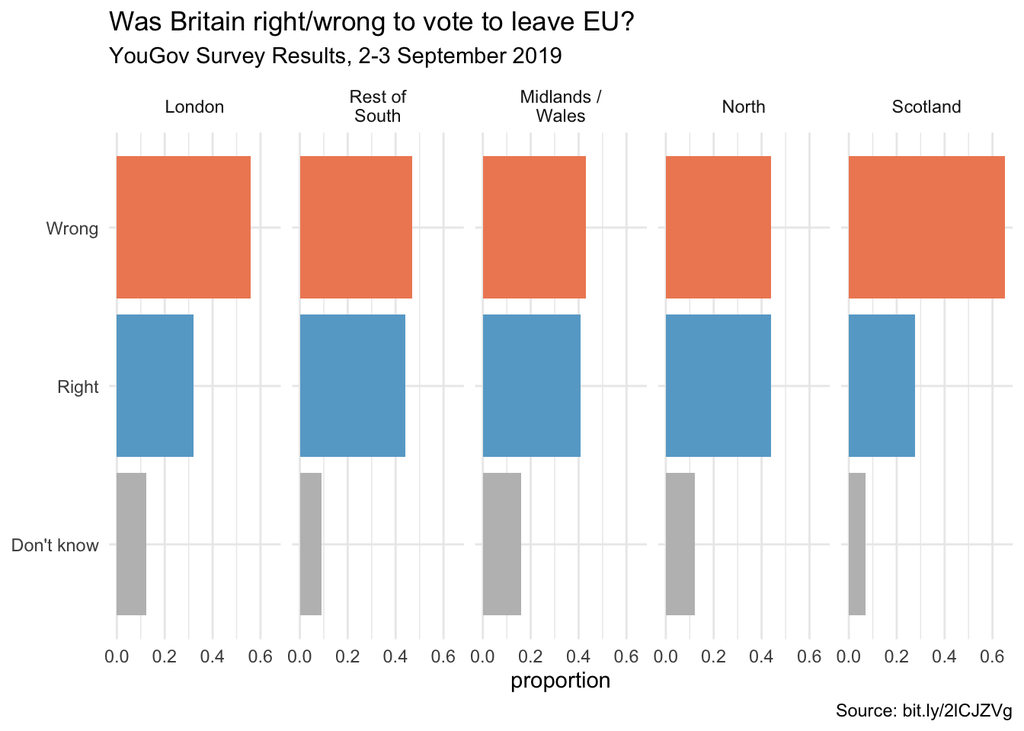

```r
#Changing fill colors and adding minimal theme.
ggplot(brexit_proportions, aes(x = proportion, y = opinion, fill = opinion)) +
  geom_col() +
  facet_wrap(~region, nrow = 1, labeller = label_wrap_gen(width = 12)) +
  guides(fill = FALSE)+
  labs(
    title = "Was Britain right/wrong to vote to leave EU?",
    subtitle = "YouGov Survey Results, 2-3 September 2019",
    caption = "Source: bit.ly/2lCJZVg",
    y = NULL
  ) +
  scale_fill_manual(values = c(
    "Wrong" = "#ef8a62",
    "Right" = "#67a9cf",
    "Don't know" = "gray"
  )) +
  theme_minimal()
```

How is the story this visualisation telling different than the story the original plot tells?

Recreate the same visualisation from the previous exercise, this time dodging the bars for opinion proportions for each region, rather than faceting by region and then improve the legend. How is the story this visualisation telling different than the story the previous plot tells?

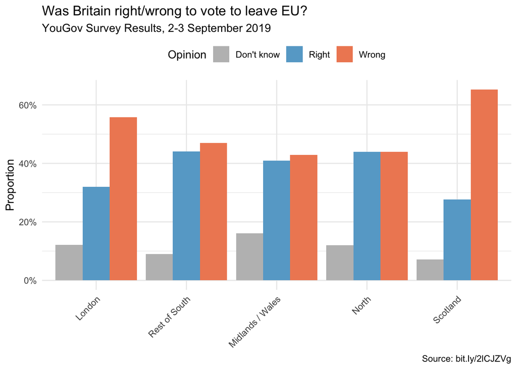

```r
# Thanks Claude
ggplot(brexit_proportions, aes(x = region, y = proportion, fill = opinion)) +
  geom_col(position = "dodge") +  # This creates the side-by-side bars
  labs(
    title = "Was Britain right/wrong to vote to leave EU?",
    subtitle = "YouGov Survey Results, 2-3 September 2019",
    caption = "Source: bit.ly/2lCJZVg",
    x = NULL,
    y = "Proportion"
  ) +
  scale_fill_manual(values = c(
    "Wrong" = "#ef8a62",
    "Right" = "#67a9cf",
    "Don't know" = "gray"
  ),
  name = "Opinion") +  # Improves the legend title
  scale_y_continuous(labels = scales::percent_format()) +  # Format y-axis as percentages
  theme_minimal() +
  theme(
    axis.text.x = element_text(angle = 45, hjust = 1),  # Angle the x-axis labels for better readability
    legend.position = "top"  # Move legend to top for better visibility
  )
```